# Industrial failure data analysis

2021-02-03

## Observed failure rates

- Set of 1507 (A) + 756 (B) experiments.
- \(p_A=\) 2.86% with version 1.4.
- \(p_B=\) 2.12% with version 1.5.
- \(p_B- p_A=\) -0.73%

## Uncertainty in failure rate estimates

- Failure rates estimated on limited samples.
- Uncertainty attached to observed failure rates captured by confidence intervals:
  - \(CI_{0.95}(p_A)=\) [ 2.08 , 3.83]
  - \(CI_{0.95}(p_B)=\) [ 1.22 , 3.43]
  - \(CI_{0.95}(p_B-p_A)=\) [ -1.8 , 0.491]
- We can not confidently rule out the hypothesis that the reduction in failure rate was observed by chance

## Association version-failure

- Fisher exact test
- Null hypothesis: independence of joint distribution [version,failure]
- p-value = 0.33
- We can not confidently rule out the hypothesis that the association was observed by chance

## Relevance of statistical testing theory in present context

- Testing theory relevant to control type I error (asymetric situation)
- Here **in absence of specific knowledge about update and failure costs**, choosing version 1.5 over 1.4 or vice versa are equivalent

## Uncertainty of financial cost

Denoting

- \(C_A\), \(C_B\) cost under scenario \(A\) and \(B\),
- \(C_u\) cost update,
- \(C_f\) cost individual failure,
- \(n\) number of runs

Then

- \(C_B -C_A = C_u + C_f \times n \times (p_B - p_A)\)
- \(CI(C_B -C_A) = C_u + C_f \times n \times CI(p_B - p_A)\)

## Uncertainty of financial cost (cont’)

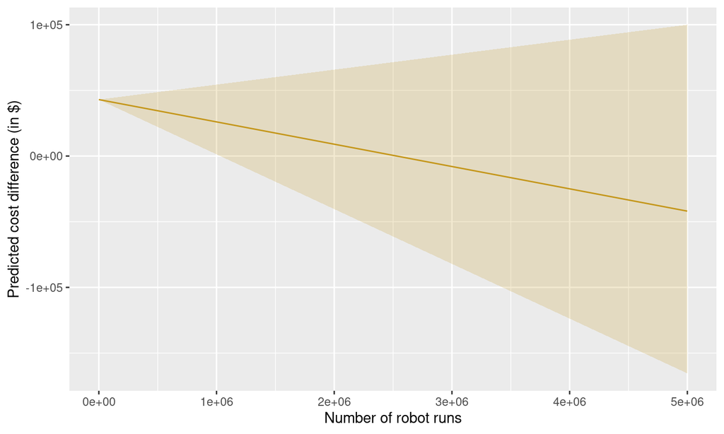

## Appendix: confidence interval for a difference of proportions

- Many methods exist, all approximate or based on assumptions
- Newcombe (1998) reviewed eleven methods
- Method based on the Wilson score Wilson (1927) appears as the best combination between computational convenience and accuracy.

## References

Full R code: github.com/gilles-guillot/Dream-Inc

Newcombe, Robert G. 1998. “Interval Estimation for the Difference Between Independent Proportions: Comparison of Eleven Methods.” *Statistics in Medicine* 17 (8): 873–90.

Wilson, Edwin B. 1927. “Probable Inference, the Law of Succession, and Statistical Inference.” *Journal of the American Statistical Association* 22 (158): 209–12.